# Clusters socio-digitales en el Gran Santiago: brecha digital, migración y escolaridad (CASEN–Censo 2017)

Kurt Gee Castañer

2025-11-25

# 1 1. Introducción

El acceso a Internet por banda ancha móvil se ha convertido en un componente clave de la inclusión social, económica y educativa en las ciudades contemporáneas.  
En la Región Metropolitana de Santiago, esta dimensión se superpone con patrones históricos de segregación urbana, configurando una brecha digital territorial que no solo refleja diferencias tecnológicas, sino también desigualdades estructurales en ingreso, educación y composición demográfica.

En el anterior se construyó un indicador sintético de porcentaje de hogares con acceso a Internet por banda ancha móvil a nivel de zona censal urbana del Gran Santiago, a partir de la integración de la Encuesta CASEN 2017 y el Censo 2017 mediante técnicas de microsimulación.  
El resultado fue una capa espacial denominada `zonas_gs_bamovil`, donde la variable `porc_bamovil` resume la proporción estimada de hogares conectados en cada zona censal.

El objetivo de este Trabajo 3 es avanzar desde la descripción de la brecha digital hacia una caracterización tipológica del territorio, incorporando otras dimensiones sociodemográficas relevantes.  
Para ello se combinan tres variables:

[output not shown]

```r
## 1. LIBRERÍAS

library(factoextra)
library(ggfortify)
library(plotly)
library(DBI)
library(RPostgres)
library(sf)
library(ggplot2)
library(cowplot)
library(GGally)
library(dplyr)
library(viridis)
```

```r
zonas_gs_bamovil <- st_read("output/zonas_gs_bamovil.geojson")
con <- dbConnect(
RPostgres::Postgres(),
dbname   = "censo2017_rm",
host     = "localhost",
port     = 5432,
user     = "postgres",
password = "Kurt12345*"
)
```

## 1.1 2.2. Construcción de indicadores censales

A partir de las tablas normalizadas del Censo 2017 en PostgreSQL se calculan dos indicadores a nivel de zona censal:

- `ptje_migrantes`: porcentaje de personas que declaran haber nacido fuera de Chile.
- `ptje_esc_mayor_16`: porcentaje de personas con escolaridad ≥ 16 años.

```r
sql_indicadores <- "
SELECT
z.geocodigo AS geocodigo,
c.nom_comuna,

-- Porcentaje de migrantes
ROUND(
COUNT(*) FILTER (WHERE p.p12 NOT IN (1, 2, 98, 99)) * 100.0
/ NULLIF(COUNT(*), 0),
2
) AS ptje_migrantes,

-- Porcentaje de personas con escolaridad mayor o igual a 16 años
ROUND(
COUNT(*) FILTER (WHERE p.escolaridad >= 16) * 100.0
/ NULLIF(COUNT(*) FILTER (WHERE p.escolaridad IS NOT NULL), 0),
2
) AS ptje_esc_mayor_16

FROM public.personas   AS p
JOIN public.hogares    AS h ON p.hogar_ref_id    = h.hogar_ref_id
JOIN public.viviendas  AS v ON h.vivienda_ref_id = v.vivienda_ref_id
JOIN public.zonas      AS z ON v.zonaloc_ref_id  = z.zonaloc_ref_id
JOIN public.comunas    AS c ON z.codigo_comuna   = c.codigo_comuna

GROUP BY z.geocodigo, c.nom_comuna
ORDER BY ptje_esc_mayor_16 DESC;
"

df_indicadores <- dbGetQuery(con, sql_indicadores)
head(df_indicadores)
```

```
##     geocodigo  nom_comuna ptje_migrantes ptje_esc_mayor_16
## 1 13124082008    PUDAHUEL           0.00             67.74
## 2 13114131002  LAS CONDES          25.08             67.41
## 3 13123081004 PROVIDENCIA          21.28             66.02
## 4 13114011007  LAS CONDES          21.31             65.95
## 5 13114131004  LAS CONDES          32.08             65.76
## 6 13114031007  LAS CONDES          18.21             65.51
```

## 1.2 2.3. Unión de brecha digital + indicadores censales

Aquí se integra la variable microsimulada (`porc_bamovil`) con las variables del Censo (`ptje_migrantes`, `ptje_esc_mayor_16`) a nivel de zona censal.  
Esta capa será la base del análisis de clusters.

```r
zonas_gs_bamovil$geocodigo <- as.character(zonas_gs_bamovil$geocodigo)
df_indicadores$geocodigo <- as.character(df_indicadores$geocodigo)



zonas_gs_indicadores <- zonas_gs_bamovil %>%
left_join(df_indicadores, by = "geocodigo")



zonas_gs_indicadores <- zonas_gs_indicadores %>%
mutate(
nom_comuna = dplyr::coalesce(nom_comuna.x, nom_comuna.y)
) %>%
select(
tid,
geocodigo,
nom_comuna,
nom_provin,
nom_zona,
urbano,
porc_bamovil,
ptje_migrantes,
ptje_esc_mayor_16,
geometry
)



zonas_gs_indicadores <- zonas_gs_indicadores %>%
filter(
!is.na(porc_bamovil),
!is.na(ptje_migrantes),
!is.na(ptje_esc_mayor_16)
)



zonas_gs_indicadores %>%
st_drop_geometry() %>%
head()
```

```
##    tid   geocodigo nom_comuna nom_provin   nom_zona urbano porc_bamovil
## 1  755 13101091004   SANTIAGO   SANTIAGO   SANTIAGO      1     35.70220
## 2  770 13112071006 LA PINTANA   SANTIAGO LA PINTANA      1     67.00847
## 3 1705 13120011008      ÑUÑOA   SANTIAGO      ÑUÑOA      1     53.51171
## 4 2322 13101141003   SANTIAGO   SANTIAGO   SANTIAGO      1     38.31266
## 5  688 13110031007 LA FLORIDA   SANTIAGO LA FLORIDA      1     62.15820
## 6 2323 13101161001   SANTIAGO   SANTIAGO   SANTIAGO      1     38.70597
##   ptje_migrantes ptje_esc_mayor_16
## 1          24.97             20.37
## 2           0.97              5.15
## 3          12.73             57.79
## 4          31.47             44.53
## 5           3.35             22.50
## 6          29.31             44.71
```

En esta etapa quedan claramente definidas:

- **Variable microsimulada:** `porc_bamovil` (brecha digital / acceso BAMóvil).
- **Variables de Censo:** `ptje_migrantes` (migración) y `ptje_esc_mayor_16` (escolaridad alta).

## 1.3 2.4. Preparación de variables para clustering

Se seleccionan las tres variables numéricas y se escalan para que tengan media 0 y desviación estándar 1, evitando que la magnitud de una variable domine el resultado del algoritmo.

```r
vars_clusters <- zonas_gs_indicadores %>%
st_drop_geometry() %>%
dplyr::select(
porc_bamovil,        # acceso BAMóvil (microsimulación)
ptje_migrantes,      # % migrantes
ptje_esc_mayor_16    # % con >= 16 años de escolaridad
)

vars_scaled <- scale(vars_clusters)

summary(vars_clusters)
```

```
##   porc_bamovil   ptje_migrantes   ptje_esc_mayor_16
##  Min.   :15.48   Min.   : 0.000   Min.   : 0.00
##  1st Qu.:41.90   1st Qu.: 2.530   1st Qu.: 8.78
##  Median :53.43   Median : 4.560   Median :14.20
##  Mean   :50.70   Mean   : 8.127   Mean   :21.21
##  3rd Qu.:60.14   3rd Qu.: 9.170   3rd Qu.:29.54
##  Max.   :77.78   Max.   :60.480   Max.   :67.41
```

```r
summary(vars_scaled)
```

```
##   porc_bamovil     ptje_migrantes    ptje_esc_mayor_16
##  Min.   :-2.8563   Min.   :-0.8758   Min.   :-1.2923
##  1st Qu.:-0.7142   1st Qu.:-0.6032   1st Qu.:-0.7573
##  Median : 0.2212   Median :-0.3844   Median :-0.4270
##  Mean   : 0.0000   Mean   : 0.0000   Mean   : 0.0000
##  3rd Qu.: 0.7654   3rd Qu.: 0.1124   3rd Qu.: 0.5079
##  Max.   : 2.1954   Max.   : 5.6419   Max.   : 2.8157
```

# 2 3. Análisis de clusters (k-means)

## 2.1 3.1. Elección del número de clusters (método del codo)

Para elegir el número de grupos `k`, se utiliza el método del codo, que evalúa la suma de cuadrados intra-cluster (WSS) para distintos valores de `k`.  
El “codo” del gráfico indica un punto a partir del cual agregar más clusters aporta poca reducción adicional de la inercia.

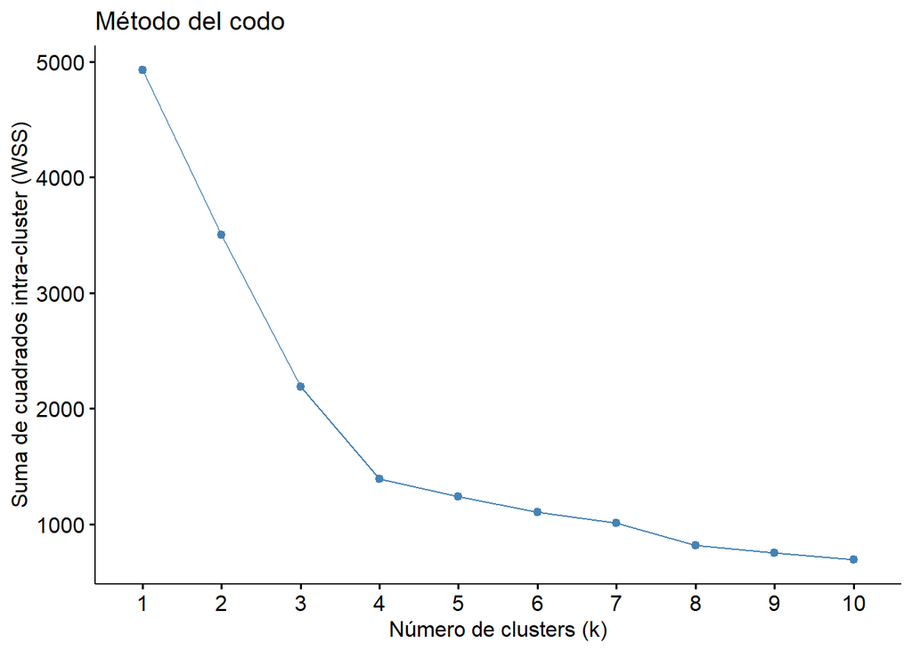

```r
## 7. MÉTODO DEL CODO

fviz_nbclust(vars_scaled, kmeans, method = "wss") +
labs(
title = "Método del codo",
x = "Número de clusters (k)",
y = "Suma de cuadrados intra-cluster (WSS)"
)
```

En este trabajo se adopta **k = 4**, ya que:

- El gráfico del codo muestra una disminución marcada del WSS hasta aproximadamente 4 clusters, y el uso de 4 grupos permite una interpretación más rica de los perfiles socio-digitales, diferenciando mejor entre zonas con brecha digital alta, media y baja, combinadas con distintos niveles de migración y escolaridad.

## 2.2 3.2. Clasificación k-means con k = 4

```r
set.seed(123)
km <- kmeans(vars_scaled, centers = 4, nstart = 25)

# Agregar cluster a la capa espacial

zonas_gs_indicadores$cluster <- as.factor(km$cluster)

# Resumen de medias por cluster (interpretación cuantitativa)

resumen_clusters <- aggregate(
vars_clusters,
by = list(cluster = zonas_gs_indicadores$cluster),
FUN = mean
)

resumen_clusters
```

```
##   cluster porc_bamovil ptje_migrantes ptje_esc_mayor_16
## 1       1     35.01548       5.397507          11.45593
## 2       2     57.66200      10.200611          47.79466
## 3       3     57.15288       3.877863          12.89231
## 4       4     40.79797      32.069177          34.00114
```

Cada fila de `resumen_clusters` resume el perfil promedio de las zonas en cada cluster en términos de:

- Porcentaje de hogares con acceso a BAMóvil (`porc_bamovil`),
- Porcentaje de migrantes (`ptje_migrantes`)
- Porcentaje con ≥ 16 años de escolaridad (`ptje_esc_mayor_16`).

A partir de esta tabla se pueden identificar, por ejemplo:

- Clusters con alta conectividad y alta escolaridad
- Clusters con baja conectividad y baja escolaridad
- Clusters con alta presencia migrante y niveles intermedios de acceso, etc.
- La interpretación específica depende de los valores que arroje la ejecución del código.

## 2.3 3.3. Gráficos de dispersión

Se representan las relaciones entre las variables y los clusters en el espacio de atributos.

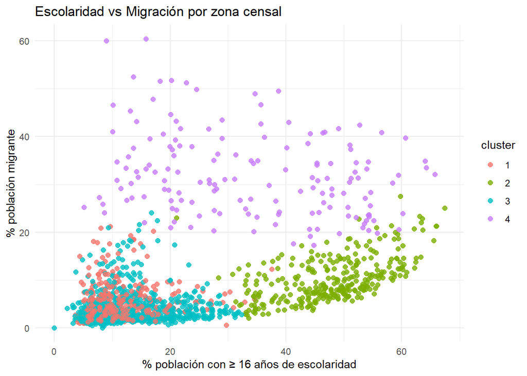

```r
ggplot(
zonas_gs_indicadores %>% st_drop_geometry(),
aes(x = ptje_esc_mayor_16, y = ptje_migrantes, color = cluster)
) +
geom_point(size = 2, alpha = 0.8) +
labs(
title = "Escolaridad vs Migración por zona censal",
x = "% población con ≥ 16 años de escolaridad",
y = "% población migrante"
) +
theme_minimal()
```

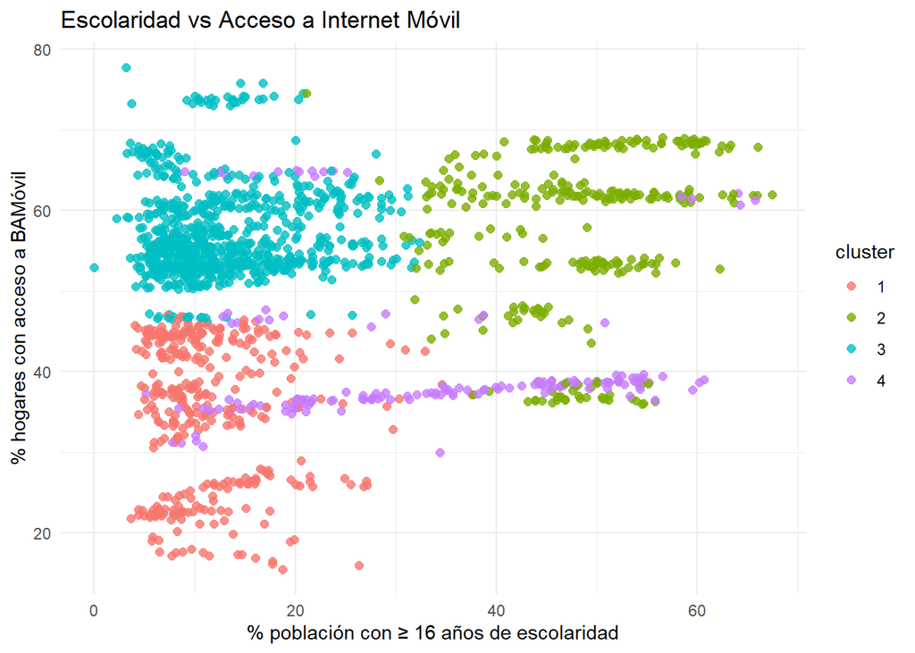

```r
ggplot(
zonas_gs_indicadores %>% st_drop_geometry(),
aes(x = ptje_esc_mayor_16, y = porc_bamovil, color = cluster)
) +
geom_point(size = 2, alpha = 0.8) +
labs(
title = "Escolaridad vs Acceso a Internet Móvil",
x = "% población con ≥ 16 años de escolaridad",
y = "% hogares con acceso a BAMóvil"
) +
theme_minimal()
```

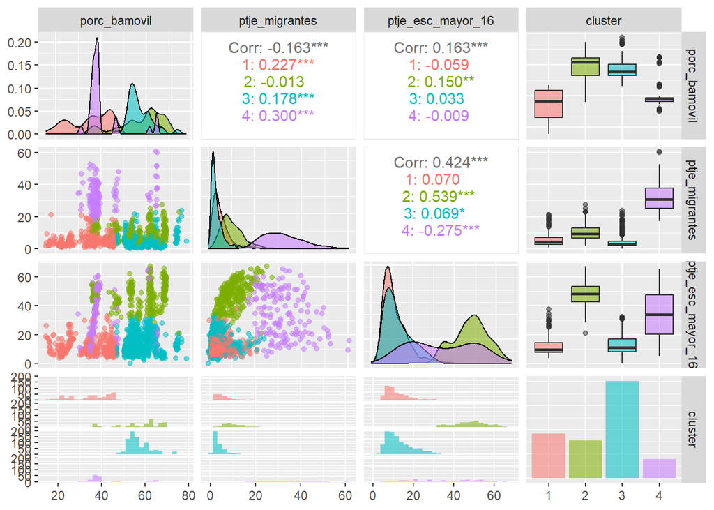

```r
GGally::ggpairs(
zonas_gs_indicadores %>%
st_drop_geometry() %>%
dplyr::select(porc_bamovil, ptje_migrantes, ptje_esc_mayor_16, cluster),
aes(color = cluster, alpha = 0.7)
)
```

Estos gráficos permiten observar si, por ejemplo:

- Los clusters con mayor escolaridad se asocian a mayores niveles de acceso a Internet móvil
- Existen clusters con alta participación migrante y niveles intermedios o bajos de conectividad.